================================================================================ DEEP NEURAL NETWORKS - ASSIGNMENT : CNN FOR IMAGE CLASSIFICATION

# Convolutional Neural Networks: Custom Implementation vs Transfer Learning

================================================================================

# STUDENT INFORMATION (REQUIRED - DO NOT DELETE)

BITS ID: 2024ac05452 Name: BORPHALKAR MADHUKAR RAJESH . Email: 2024ac05452@wilp.bits-pilani.ac.in Date: 12/02/2026

================================================================================

================================================================================

# ASSIGNMENT OVERVIEW

This assignment requires you to implement and compare two CNN approaches for image classification:

1. Custom CNN architecture using Keras/PyTorch
2. Transfer Learning using pre-trained models (ResNet/VGG)

Learning Objectives:

- Design CNN architectures with Global Average Pooling
- Apply transfer learning with pre-trained models
- Compare custom vs pre-trained model performance
- Use industry-standard deep learning frameworks

IMPORTANT: Global Average Pooling (GAP) is MANDATORY for both models. DO NOT use Flatten + Dense layers in the final architecture.

================================================================================

```python
# Import Required Libraries
import numpy as np
import pandas as pd
import matplotlib.pyplot as plt
import seaborn as sns
from sklearn.model_selection import train_test_split
from sklearn.metrics import accuracy_score, precision_score, recall_score, f1_score
from sklearn.metrics import confusion_matrix, classification_report
import time
import json
import os

# Deep learning frameworks (choose Keras or PyTorch)
# For image processing
from PIL import Image
import cv2
```

================================================================================

# PART 1: DATASET LOADING AND EXPLORATION (Informational)

Instructions:

1. Choose ONE dataset from the allowed list
2. Load and explore the data
3. Fill in ALL required metadata fields below
4. Provide justification for your primary metric choice

ALLOWED DATASETS:

- Cats vs Dogs (2 classes)
- Food-101 subset (10-20 classes)
- Plant Disease (3-5 classes)
- Medical Images (2-3 classes)
- Custom dataset (with IC approval, min 500 images per class)

REQUIRED OUTPUT:

- Print all metadata fields
- Brief EDA with visualizations
- Data distribution analysis

================================================================================

```
WARNING:absl:Variant folder /root/tensorflow_datasets/malaria/1.0.0 has no dataset_info.json
```

```
Downloading and preparing dataset Unknown size (download: Unknown size, generated: Unknown size, total: Unknown size) to /root/tensorflow_datasets/malaria/1.0.0...
```

```
Dataset malaria downloaded and prepared to /root/tensorflow_datasets/malaria/1.0.0. Subsequent calls will reuse this data.

======================================================================
DATASET INFORMATION
======================================================================
Dataset: Malaria Cell Images (TFDS)
Source: TensorFlow Datasets (malaria)
Total Samples: 27558
Number of Classes: 2 -> ['parasitized', 'uninfected']
Samples per Class (summary): train min: 10530, max: 10552, avg: 10541 | test min: 2045, max: 2089, avg: 2067
Image Shape: [224, 224, 3]
Train/Test Split: 85/15
Training Samples (after val split): 21082
Validation Samples (from train): 2342
Test Samples: 4134
Train Counts by Class: {'parasitized': 10530, 'uninfected': 10552}
Val Counts by Class:   {'parasitized': 1160, 'uninfected': 1182}
Test Counts by Class:  {'parasitized': 2089, 'uninfected': 2045}
Primary Metric: accuracy
Metric Justification: Accuracy is appropriate for this 2-class medical classification task as an overall correctness measure; precision/recall/F1 are additionally reported (macro) as required.
======================================================================
```

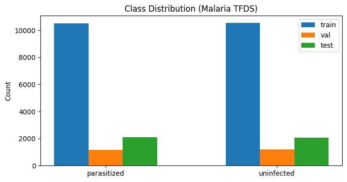

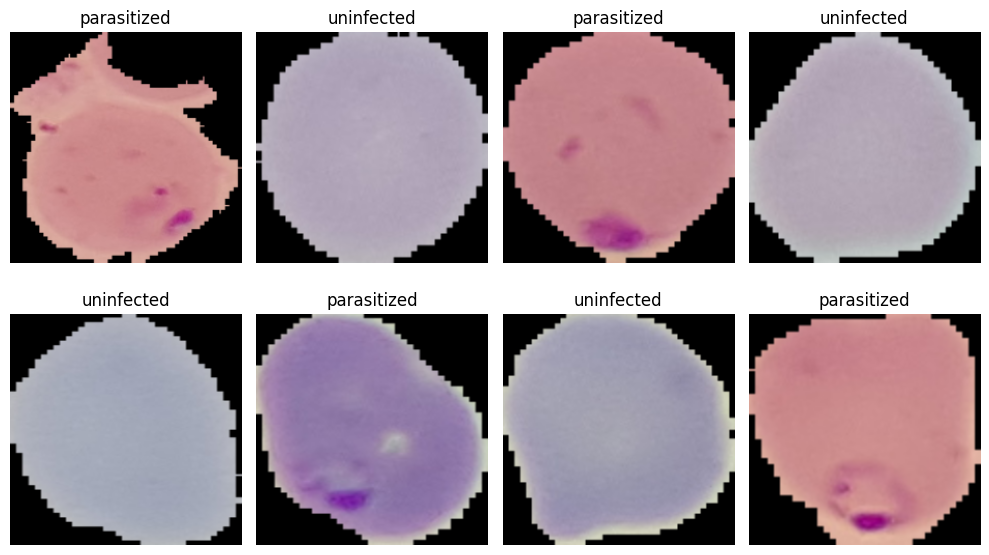

```python
# =========================
# PART 1: DATASET LOADING + EDA
# Dataset: MALARIA (TFDS) - Medical Images (2 Classes)
# =========================

import tensorflow_datasets as tfds
import tensorflow as tf
from tensorflow import keras
from tensorflow.keras import layers

SEED = 42
tf.random.set_seed(SEED)
np.random.seed(SEED)

# REQUIRED metadata fields (template variables)
dataset_name = "Malaria Cell Images (TFDS)"
dataset_source = "TensorFlow Datasets (malaria)"
problem_type = "classification"

# Image config (good for transfer learning)
IMG_SIZE = (224, 224)
BATCH_SIZE = 32
image_shape = [IMG_SIZE[0], IMG_SIZE[1], 3]

# Load full dataset (TFDS malaria is stored under split 'train')
ds_all, ds_info = tfds.load(
    "malaria",
    split="train",
    as_supervised=True,
    with_info=True
)

# Class info from TFDS
class_names = ds_info.features["label"].names  # typically: ['parasitized', 'uninfected']
n_classes = ds_info.features["label"].num_classes

# Total samples
n_samples = ds_info.splits["train"].num_examples

# Assignment required train/test split: 85/15
train_test_ratio = "85/15"
train_size = int(0.85 * n_samples)
test_size = n_samples - train_size

# Deterministic shuffle then split
ds_all = ds_all.shuffle(10000, seed=SEED, reshuffle_each_iteration=False)
train_raw_full = ds_all.take(train_size)
test_raw = ds_all.skip(train_size)

train_samples = train_size
test_samples = test_size

# Recommended: create a validation split from training set (10% of train)
val_size = int(0.10 * train_samples)
val_raw = train_raw_full.take(val_size)
train_raw = train_raw_full.skip(val_size)

# Preprocess: resize + normalize
def preprocess(image, label):
    image = tf.image.resize(image, IMG_SIZE)
    image = tf.cast(image, tf.float32) / 255.0
    label = tf.cast(label, tf.int32)
    return image, label

train_ds = train_raw.map(preprocess).batch(BATCH_SIZE).prefetch(tf.data.AUTOTUNE)
val_ds   = val_raw.map(preprocess).batch(BATCH_SIZE).prefetch(tf.data.AUTOTUNE)
test_ds  = test_raw.map(preprocess).batch(BATCH_SIZE).prefetch(tf.data.AUTOTUNE)

# Count per-class samples (for requirement visibility)
def count_classes(ds_unbatched, n_classes):
    counts = [0] * n_classes
    for _, y in ds_unbatched:
        counts[int(y.numpy())] += 1
    return counts

train_counts = count_classes(train_raw, n_classes)
val_counts   = count_classes(val_raw, n_classes)
test_counts  = count_classes(test_raw, n_classes)

samples_per_class = (
    f"train min: {min(train_counts)}, max: {max(train_counts)}, avg: {int(np.mean(train_counts))} | "
    f"test min: {min(test_counts)}, max: {max(test_counts)}, avg: {int(np.mean(test_counts))}"
)

# Primary metric selection (required)
primary_metric = "accuracy"
metric_justification = (
    "Accuracy is appropriate for this 2-class medical classification task as an overall correctness measure; "
    "precision/recall/F1 are additionally reported (macro) as required."
)

print("\n" + "="*70)
print("DATASET INFORMATION")
print("="*70)
print(f"Dataset: {dataset_name}")
print(f"Source: {dataset_source}")
print(f"Total Samples: {n_samples}")
print(f"Number of Classes: {n_classes} -> {class_names}")
print(f"Samples per Class (summary): {samples_per_class}")
print(f"Image Shape: {image_shape}")
print(f"Train/Test Split: {train_test_ratio}")
print(f"Training Samples (after val split): {train_samples - val_size}")
print(f"Validation Samples (from train): {val_size}")
print(f"Test Samples: {test_samples}")
print(f"Train Counts by Class: {dict(zip(class_names, train_counts))}")
print(f"Val Counts by Class:   {dict(zip(class_names, val_counts))}")
print(f"Test Counts by Class:  {dict(zip(class_names, test_counts))}")
print(f"Primary Metric: {primary_metric}")
print(f"Metric Justification: {metric_justification}")
print("="*70)

# EDA: Class distribution (train/val/test)
plt.figure(figsize=(8, 4))
x = np.arange(n_classes)
plt.bar(x - 0.2, train_counts, width=0.2, label="train")
plt.bar(x,       val_counts,   width=0.2, label="val")
plt.bar(x + 0.2, test_counts,  width=0.2, label="test")
plt.xticks(x, class_names, rotation=0)
plt.title("Class Distribution (Malaria TFDS)")
plt.ylabel("Count")
plt.legend()
plt.show()

# EDA: Sample images
plt.figure(figsize=(10, 6))
for images, labels in train_ds.take(1):
    for i in range(min(8, images.shape[0])):
        plt.subplot(2, 4, i + 1)
        plt.imshow(images[i])
        plt.title(class_names[int(labels[i])])
        plt.axis("off")
plt.tight_layout()
plt.show()
```

================================================================================

# PART 2: CUSTOM CNN IMPLEMENTATION (5 MARKS)

REQUIREMENTS:

- Build CNN using Keras/PyTorch layers
- Architecture must include:
  - Conv2D layers (at least 2)
  - Pooling layers (MaxPool or AvgPool)
  - Global Average Pooling (GAP) - MANDATORY
  - Output layer (Softmax for multi-class)
- Use model.compile() and model.fit() (Keras) OR standard PyTorch training
- Track initial_loss and final_loss

PROHIBITED:

- Using Flatten + Dense layers instead of GAP
- Implementing convolution from scratch

GRADING:

- Architecture design with GAP: 2 marks
- Model properly compiled/configured: 1 mark
- Training completed with loss tracking: 1 mark
- All metrics calculated correctly: 1 mark

================================================================================

```
Model: "custom_cnn_gap"
```

```
┏━━━━━━━━━━━━━━━━━━━━━━━━━━━━━━━━━┳━━━━━━━━━━━━━━━━━━━━━━━━┳━━━━━━━━━━━━━━━┓
┃ Layer (type)                    ┃ Output Shape           ┃       Param # ┃
┡━━━━━━━━━━━━━━━━━━━━━━━━━━━━━━━━━╇━━━━━━━━━━━━━━━━━━━━━━━━╇━━━━━━━━━━━━━━━┩
│ input_layer_1 (InputLayer)      │ (None, 224, 224, 3)    │             0 │
├─────────────────────────────────┼────────────────────────┼───────────────┤
│ conv2d_3 (Conv2D)               │ (None, 224, 224, 32)   │           896 │
├─────────────────────────────────┼────────────────────────┼───────────────┤
│ batch_normalization_3           │ (None, 224, 224, 32)   │           128 │
│ (BatchNormalization)            │                        │               │
├─────────────────────────────────┼────────────────────────┼───────────────┤
│ re_lu_3 (ReLU)                  │ (None, 224, 224, 32)   │             0 │
├─────────────────────────────────┼────────────────────────┼───────────────┤
│ max_pooling2d_2 (MaxPooling2D)  │ (None, 112, 112, 32)   │             0 │
├─────────────────────────────────┼────────────────────────┼───────────────┤
│ conv2d_4 (Conv2D)               │ (None, 112, 112, 64)   │        18,496 │
├─────────────────────────────────┼────────────────────────┼───────────────┤
│ batch_normalization_4           │ (None, 112, 112, 64)   │           256 │
│ (BatchNormalization)            │                        │               │
├─────────────────────────────────┼────────────────────────┼───────────────┤
│ re_lu_4 (ReLU)                  │ (None, 112, 112, 64)   │             0 │
├─────────────────────────────────┼────────────────────────┼───────────────┤
│ max_pooling2d_3 (MaxPooling2D)  │ (None, 56, 56, 64)     │             0 │
├─────────────────────────────────┼────────────────────────┼───────────────┤
│ conv2d_5 (Conv2D)               │ (None, 56, 56, 128)    │        73,856 │
├─────────────────────────────────┼────────────────────────┼───────────────┤
│ batch_normalization_5           │ (None, 56, 56, 128)    │           512 │
│ (BatchNormalization)            │                        │               │
├─────────────────────────────────┼────────────────────────┼───────────────┤
│ re_lu_5 (ReLU)                  │ (None, 56, 56, 128)    │             0 │
├─────────────────────────────────┼────────────────────────┼───────────────┤
│ global_average_pooling2d_1      │ (None, 128)            │             0 │
│ (GlobalAveragePooling2D)        │                        │               │
├─────────────────────────────────┼────────────────────────┼───────────────┤
│ dropout_1 (Dropout)             │ (None, 128)            │             0 │
├─────────────────────────────────┼────────────────────────┼───────────────┤
│ dense_1 (Dense)                 │ (None, 2)              │           258 │
└─────────────────────────────────┴────────────────────────┴───────────────┘
```

```
 Total params: 94,402 (368.76 KB)
```

```
 Trainable params: 93,954 (367.01 KB)
```

```
 Non-trainable params: 448 (1.75 KB)
```

```
======================================================================
CUSTOM CNN TRAINING
======================================================================
659/659 ━━━━━━━━━━━━━━━━━━━━ 66s 77ms/step - accuracy: 0.6744 - loss: 0.6133 - val_accuracy: 0.9001 - val_loss: 0.4926 - learning_rate: 0.0010
659/659 ━━━━━━━━━━━━━━━━━━━━ 51s 67ms/step - accuracy: 0.8392 - loss: 0.4289 - val_accuracy: 0.5047 - val_loss: 1.0262 - learning_rate: 0.0010
659/659 ━━━━━━━━━━━━━━━━━━━━ 51s 68ms/step - accuracy: 0.8766 - loss: 0.3689 - val_accuracy: 0.8190 - val_loss: 1.3836 - learning_rate: 0.0010
659/659 ━━━━━━━━━━━━━━━━━━━━ 51s 69ms/step - accuracy: 0.8976 - loss: 0.3323 - val_accuracy: 0.9103 - val_loss: 0.4017 - learning_rate: 5.0000e-04
659/659 ━━━━━━━━━━━━━━━━━━━━ 51s 69ms/step - accuracy: 0.9090 - loss: 0.2878 - val_accuracy: 0.9321 - val_loss: 0.4471 - learning_rate: 5.0000e-04
659/659 ━━━━━━━━━━━━━━━━━━━━ 51s 69ms/step - accuracy: 0.9226 - loss: 0.2469 - val_accuracy: 0.9364 - val_loss: 0.2504 - learning_rate: 5.0000e-04
659/659 ━━━━━━━━━━━━━━━━━━━━ 51s 70ms/step - accuracy: 0.9284 - loss: 0.2195 - val_accuracy: 0.9321 - val_loss: 0.2055 - learning_rate: 5.0000e-04
659/659 ━━━━━━━━━━━━━━━━━━━━ 51s 70ms/step - accuracy: 0.9354 - loss: 0.2085 - val_accuracy: 0.9368 - val_loss: 0.1988 - learning_rate: 5.0000e-04
659/659 ━━━━━━━━━━━━━━━━━━━━ 51s 69ms/step - accuracy: 0.9347 - loss: 0.2083 - val_accuracy: 0.9419 - val_loss: 0.1841 - learning_rate: 5.0000e-04
659/659 ━━━━━━━━━━━━━━━━━━━━ 51s 68ms/step - accuracy: 0.9369 - loss: 0.1920 - val_accuracy: 0.9436 - val_loss: 0.1752 - learning_rate: 5.0000e-04
Training completed in 524.85 seconds
Initial Loss: 0.5543
Final Loss: 0.1985
Custom CNN Loss Reduction: 64.18%
======================================================================

Custom CNN Performance:
Accuracy:  0.9393
Precision: 0.9416
Recall:    0.9397
F1-Score:  0.9392

Classification Report (Custom CNN):
              precision    recall  f1-score   support

 parasitized       0.98      0.90      0.94      2089
  uninfected       0.91      0.98      0.94      2045

    accuracy                           0.94      4134
   macro avg       0.94      0.94      0.94      4134
weighted avg       0.94      0.94      0.94      4134
```

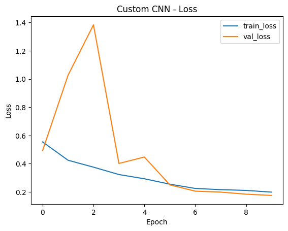

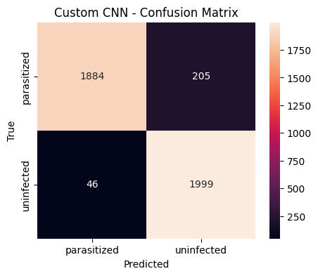

```python
IMG_SIZE = (224, 224)

custom_cnn = build_custom_cnn((IMG_SIZE[0], IMG_SIZE[1], 3), n_classes)


def build_custom_cnn(input_shape, n_classes):
    """
    Custom CNN with Global Average Pooling (MANDATORY).
    NO Flatten layers used.
    """
    inputs = keras.Input(shape=input_shape)

    x = layers.Conv2D(32, 3, padding="same")(inputs)
    x = layers.BatchNormalization()(x)
    x = layers.ReLU()(x)
    x = layers.MaxPooling2D()(x)

    x = layers.Conv2D(64, 3, padding="same")(x)
    x = layers.BatchNormalization()(x)
    x = layers.ReLU()(x)
    x = layers.MaxPooling2D()(x)

    x = layers.Conv2D(128, 3, padding="same")(x)
    x = layers.BatchNormalization()(x)
    x = layers.ReLU()(x)

    # MANDATORY: Global Average Pooling
    x = layers.GlobalAveragePooling2D()(x)

    x = layers.Dropout(0.3)(x)
    outputs = layers.Dense(n_classes, activation="softmax")(x)

    model = keras.Model(inputs, outputs, name="custom_cnn_gap")
    model.compile(
        optimizer=keras.optimizers.Adam(learning_rate=1e-3),
        loss="sparse_categorical_crossentropy",
        metrics=["accuracy"]
    )
    return model

custom_cnn = build_custom_cnn((IMG_SIZE[0], IMG_SIZE[1], 3), n_classes)
custom_cnn.summary()

print("\n" + "="*70)
print("CUSTOM CNN TRAINING")
print("="*70)


callbacks = [
    keras.callbacks.EarlyStopping(
        monitor="val_loss",
        patience=3,
        restore_best_weights=True
    ),
    keras.callbacks.ReduceLROnPlateau(
        monitor="val_loss",
        factor=0.5,
        patience=2,
        min_lr=1e-6
    ),
]

custom_cnn_start_time = time.time()
history_custom = custom_cnn.fit(
    train_ds,
    validation_data=val_ds,
    epochs=10,
    callbacks=callbacks
)
custom_cnn_training_time = time.time() - custom_cnn_start_time

custom_cnn_initial_loss = float(history_custom.history["loss"][0])
custom_cnn_final_loss = float(history_custom.history["loss"][-1])

print(f"Training completed in {custom_cnn_training_time:.2f} seconds")
print(f"Initial Loss: {custom_cnn_initial_loss:.4f}")
print(f"Final Loss: {custom_cnn_final_loss:.4f}")

# Loss reduction %
custom_reduction = ((custom_cnn_initial_loss - custom_cnn_final_loss) / custom_cnn_initial_loss) * 100
print(f"Custom CNN Loss Reduction: {custom_reduction:.2f}%")
print("="*70)

# =========================
# Evaluate on test set
# =========================
y_true = []
y_pred = []

for x_batch, y_batch in test_ds:
    probs = custom_cnn.predict(x_batch, verbose=0)
    preds = np.argmax(probs, axis=1)
    y_true.extend(y_batch.numpy().tolist())
    y_pred.extend(preds.tolist())

custom_cnn_accuracy = float(accuracy_score(y_true, y_pred))
custom_cnn_precision = float(precision_score(y_true, y_pred, average="macro", zero_division=0))
custom_cnn_recall = float(recall_score(y_true, y_pred, average="macro", zero_division=0))
custom_cnn_f1 = float(f1_score(y_true, y_pred, average="macro", zero_division=0))

print("\nCustom CNN Performance:")
print(f"Accuracy:  {custom_cnn_accuracy:.4f}")
print(f"Precision: {custom_cnn_precision:.4f}")
print(f"Recall:    {custom_cnn_recall:.4f}")
print(f"F1-Score:  {custom_cnn_f1:.4f}")

# Optional (helpful): classification report
print("\nClassification Report (Custom CNN):")
print(classification_report(y_true, y_pred, target_names=class_names, zero_division=0))

# =========================
# Visualizations
# =========================

# Training curves (loss)
plt.figure()
plt.plot(history_custom.history["loss"], label="train_loss")
plt.plot(history_custom.history["val_loss"], label="val_loss")
plt.title("Custom CNN - Loss")
plt.xlabel("Epoch")
plt.ylabel("Loss")
plt.legend()
plt.show()

# Confusion matrix
cm = confusion_matrix(y_true, y_pred)
plt.figure(figsize=(5, 4))
sns.heatmap(cm, annot=True, fmt="d", xticklabels=class_names, yticklabels=class_names)
plt.title("Custom CNN - Confusion Matrix")
plt.ylabel("True")
plt.xlabel("Predicted")
plt.show()
```

================================================================================

# PART 3: TRANSFER LEARNING IMPLEMENTATION (5 MARKS)

REQUIREMENTS:

- Use pre-trained model: ResNet18/ResNet50 OR VGG16/VGG19
- Freeze base layers (feature extractor)
- Replace final layers with:
  - Global Average Pooling (GAP) - MANDATORY
  - Custom classification head
- Fine-tune on your dataset
- Track initial_loss and final_loss

GRADING:

- Valid base model with frozen layers: 2 marks
- GAP + custom head properly implemented: 1 mark
- Training completed with loss tracking: 1 mark
- All metrics calculated correctly: 1 mark

================================================================================

```
Downloading data from https://storage.googleapis.com/tensorflow/keras-applications/resnet/resnet50_weights_tf_dim_ordering_tf_kernels_notop.h5
94765736/94765736 ━━━━━━━━━━━━━━━━━━━━ 0s 0us/step

======================================================================
TRANSFER LEARNING MODEL SUMMARY
======================================================================
```

```
Model: "ResNet50_transfer_gap"
```

```
┏━━━━━━━━━━━━━━━━━━━━━━━━━━━━━━━━━┳━━━━━━━━━━━━━━━━━━━━━━━━┳━━━━━━━━━━━━━━━┓
┃ Layer (type)                    ┃ Output Shape           ┃       Param # ┃
┡━━━━━━━━━━━━━━━━━━━━━━━━━━━━━━━━━╇━━━━━━━━━━━━━━━━━━━━━━━━╇━━━━━━━━━━━━━━━┩
│ input_layer_3 (InputLayer)      │ (None, 224, 224, 3)    │             0 │
├─────────────────────────────────┼────────────────────────┼───────────────┤
│ preprocess (Lambda)             │ (None, 224, 224, 3)    │             0 │
├─────────────────────────────────┼────────────────────────┼───────────────┤
│ resnet50 (Functional)           │ (None, 7, 7, 2048)     │    23,587,712 │
├─────────────────────────────────┼────────────────────────┼───────────────┤
│ gap (GlobalAveragePooling2D)    │ (None, 2048)           │             0 │
├─────────────────────────────────┼────────────────────────┼───────────────┤
│ dropout_2 (Dropout)             │ (None, 2048)           │             0 │
├─────────────────────────────────┼────────────────────────┼───────────────┤
│ dense_2 (Dense)                 │ (None, 2)              │         4,098 │
└─────────────────────────────────┴────────────────────────┴───────────────┘
```

```
 Total params: 23,591,810 (90.00 MB)
```

```
 Trainable params: 4,098 (16.01 KB)
```

```
 Non-trainable params: 23,587,712 (89.98 MB)
```

```
======================================================================
Base Model: ResNet50
Frozen Layers (base): 175
Trainable Layers (base): 0
Total Parameters (full model): 23,591,810
Trainable Parameters (head):   4,098
Using Global Average Pooling:  YES
======================================================================

======================================================================
TRANSFER LEARNING TRAINING
======================================================================
659/659 ━━━━━━━━━━━━━━━━━━━━ 97s 117ms/step - accuracy: 0.5383 - loss: 0.7096 - val_accuracy: 0.6443 - val_loss: 0.6572 - learning_rate: 0.0010
659/659 ━━━━━━━━━━━━━━━━━━━━ 121s 97ms/step - accuracy: 0.5961 - loss: 0.6676 - val_accuracy: 0.6486 - val_loss: 0.6461 - learning_rate: 0.0010
659/659 ━━━━━━━━━━━━━━━━━━━━ 70s 98ms/step - accuracy: 0.6090 - loss: 0.6616 - val_accuracy: 0.6418 - val_loss: 0.6420 - learning_rate: 0.0010
659/659 ━━━━━━━━━━━━━━━━━━━━ 71s 100ms/step - accuracy: 0.6083 - loss: 0.6579 - val_accuracy: 0.6494 - val_loss: 0.6382 - learning_rate: 0.0010
659/659 ━━━━━━━━━━━━━━━━━━━━ 73s 101ms/step - accuracy: 0.6170 - loss: 0.6574 - val_accuracy: 0.6490 - val_loss: 0.6359 - learning_rate: 0.0010
Training completed in 431.95 seconds
Initial Loss: 0.6894
Final Loss: 0.6569
Transfer Learning Loss Reduction: 4.72%
======================================================================

Transfer Learning Performance:
Accuracy:  0.6318
Precision: 0.6341
Recall:    0.6324
F1-Score:  0.6309

Classification Report (Transfer Learning):
              precision    recall  f1-score   support

 parasitized       0.65      0.57      0.61      2089
  uninfected       0.61      0.69      0.65      2045

    accuracy                           0.63      4134
   macro avg       0.63      0.63      0.63      4134
weighted avg       0.63      0.63      0.63      4134
```

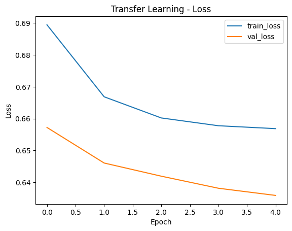

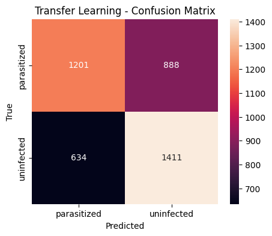

```python
pretrained_model_name = "ResNet50"

def build_transfer_learning_model(base_model_name, input_shape, n_classes):
    """
    Builds a transfer learning model with:
    - Pretrained backbone (ImageNet)
    - Frozen base layers (MANDATORY)
    - Global Average Pooling (MANDATORY)
    - NO Flatten used
    """
    if base_model_name == "ResNet50":
        base_model = keras.applications.ResNet50(
            weights="imagenet",
            include_top=False,
            input_shape=input_shape
        )
        preprocess_fn = keras.applications.resnet.preprocess_input

    elif base_model_name == "VGG16":
        base_model = keras.applications.VGG16(
            weights="imagenet",
            include_top=False,
            input_shape=input_shape
        )
        preprocess_fn = keras.applications.vgg16.preprocess_input

    elif base_model_name == "VGG19":
        base_model = keras.applications.VGG19(
            weights="imagenet",
            include_top=False,
            input_shape=input_shape
        )
        preprocess_fn = keras.applications.vgg19.preprocess_input

    else:
        raise ValueError("Supported base_model_name: ResNet50, VGG16, VGG19")

    # MANDATORY: Freeze base model
    base_model.trainable = False

    inputs = keras.Input(shape=input_shape)

    # Preprocess input according to the chosen model
    x = layers.Lambda(preprocess_fn, name="preprocess")(inputs)

    x = base_model(x, training=False)

    # MANDATORY: Global Average Pooling
    x = layers.GlobalAveragePooling2D(name="gap")(x)

    x = layers.Dropout(0.3)(x)
    outputs = layers.Dense(n_classes, activation="softmax")(x)

    model = keras.Model(inputs, outputs, name=f"{base_model_name}_transfer_gap")

    model.compile(
        optimizer=keras.optimizers.Adam(learning_rate=1e-3),
        loss="sparse_categorical_crossentropy",
        metrics=["accuracy"]
    )
    return model, base_model


IMG_SIZE = (224, 224)
input_shape = (IMG_SIZE[0], IMG_SIZE[1], 3)

transfer_model, base_model = build_transfer_learning_model(pretrained_model_name, input_shape, n_classes)

print("\n" + "="*70)
print("TRANSFER LEARNING MODEL SUMMARY")
print("="*70)
transfer_model.summary()
print("="*70)

# Counts
frozen_layers = sum([0 if l.trainable else 1 for l in base_model.layers])
trainable_layers = sum([1 if l.trainable else 0 for l in base_model.layers])
total_parameters = int(transfer_model.count_params())
trainable_parameters = int(sum([tf.size(w).numpy() for w in transfer_model.trainable_weights]))

print(f"Base Model: {pretrained_model_name}")
print(f"Frozen Layers (base): {frozen_layers}")
print(f"Trainable Layers (base): {trainable_layers}")
print(f"Total Parameters (full model): {total_parameters:,}")
print(f"Trainable Parameters (head):   {trainable_parameters:,}")
print(f"Using Global Average Pooling:  YES")
print("="*70)


tl_callbacks = [
    keras.callbacks.EarlyStopping(monitor="val_loss", patience=2, restore_best_weights=True),
    keras.callbacks.ReduceLROnPlateau(monitor="val_loss", factor=0.5, patience=1, min_lr=1e-6),
]

print("\n" + "="*70)
print("TRANSFER LEARNING TRAINING")
print("="*70)

tl_epochs = 5
tl_start_time = time.time()
history_tl = transfer_model.fit(
    train_ds,
    validation_data=val_ds,
    epochs=tl_epochs,
    callbacks=tl_callbacks
)
tl_training_time = time.time() - tl_start_time

tl_initial_loss = float(history_tl.history["loss"][0])
tl_final_loss = float(history_tl.history["loss"][-1])
tl_reduction = ((tl_initial_loss - tl_final_loss) / tl_initial_loss) * 100

print(f"Training completed in {tl_training_time:.2f} seconds")
print(f"Initial Loss: {tl_initial_loss:.4f}")
print(f"Final Loss: {tl_final_loss:.4f}")
print(f"Transfer Learning Loss Reduction: {tl_reduction:.2f}%")
print("="*70)

# Evaluate on test set
y_true_tl = []
y_pred_tl = []

for x_batch, y_batch in test_ds:
    probs = transfer_model.predict(x_batch, verbose=0)
    preds = np.argmax(probs, axis=1)
    y_true_tl.extend(y_batch.numpy().tolist())
    y_pred_tl.extend(preds.tolist())

tl_accuracy = float(accuracy_score(y_true_tl, y_pred_tl))
tl_precision = float(precision_score(y_true_tl, y_pred_tl, average="macro", zero_division=0))
tl_recall = float(recall_score(y_true_tl, y_pred_tl, average="macro", zero_division=0))
tl_f1 = float(f1_score(y_true_tl, y_pred_tl, average="macro", zero_division=0))

print("\nTransfer Learning Performance:")
print(f"Accuracy:  {tl_accuracy:.4f}")
print(f"Precision: {tl_precision:.4f}")
print(f"Recall:    {tl_recall:.4f}")
print(f"F1-Score:  {tl_f1:.4f}")

print("\nClassification Report (Transfer Learning):")
print(classification_report(y_true_tl, y_pred_tl, target_names=class_names, zero_division=0))

# Plots: loss curve
plt.figure()
plt.plot(history_tl.history["loss"], label="train_loss")
plt.plot(history_tl.history["val_loss"], label="val_loss")
plt.title("Transfer Learning - Loss")
plt.xlabel("Epoch")
plt.ylabel("Loss")
plt.legend()
plt.show()

# Confusion matrix
cm_tl = confusion_matrix(y_true_tl, y_pred_tl)
plt.figure(figsize=(5, 4))
sns.heatmap(cm_tl, annot=True, fmt="d", xticklabels=class_names, yticklabels=class_names)
plt.title("Transfer Learning - Confusion Matrix")
plt.ylabel("True")
plt.xlabel("Predicted")
plt.show()


tl_learning_rate = 0.001
tl_batch_size = BATCH_SIZE
tl_optimizer = "Adam"
```

================================================================================

# PART 4: MODEL COMPARISON AND VISUALIZATION (Informational)

Compare both models on:

- Performance metrics
- Training time
- Model complexity
- Convergence behavior

================================================================================

```
======================================================================
MODEL COMPARISON TABLE
======================================================================
           Metric   Custom CNN  Transfer Learning
         Accuracy     0.939284       6.318336e-01
        Precision     0.941577       6.341205e-01
           Recall     0.939687       6.324459e-01
         F1-Score     0.939237       6.308811e-01
Training Time (s)   524.849605       4.319525e+02
       Parameters 94402.000000       2.359181e+07
======================================================================
```

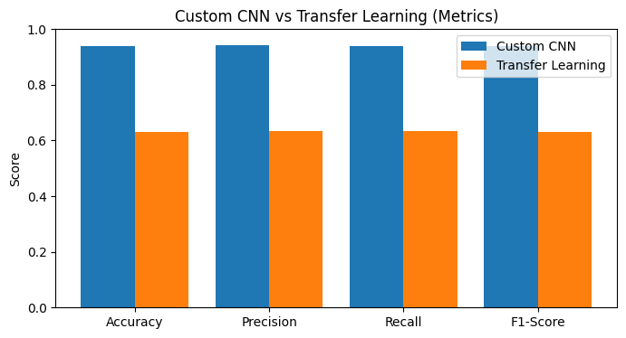

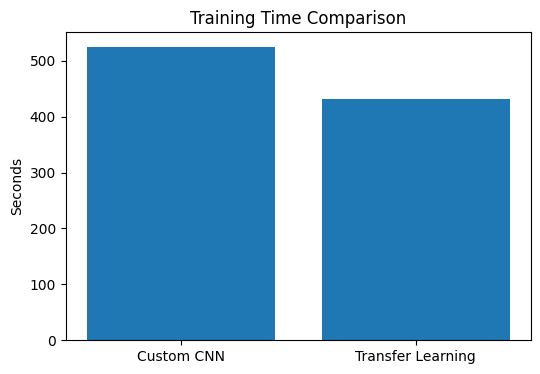

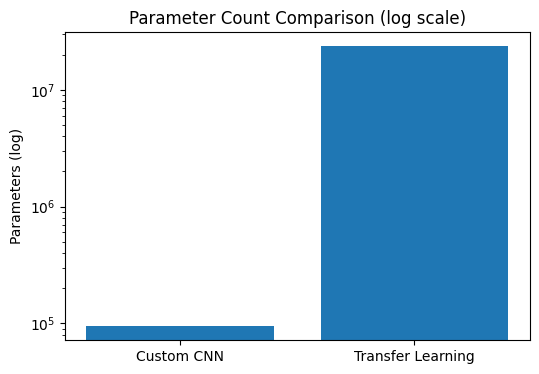

```python
# Parameters
custom_total_params = int(custom_cnn.count_params())
tl_total_params = int(transfer_model.count_params())

# Build comparison dataframe
comparison_df = pd.DataFrame({
    "Metric": ["Accuracy", "Precision", "Recall", "F1-Score", "Training Time (s)", "Parameters"],
    "Custom CNN": [
        float(custom_cnn_accuracy),
        float(custom_cnn_precision),
        float(custom_cnn_recall),
        float(custom_cnn_f1),
        float(custom_cnn_training_time),
        custom_total_params
    ],
    "Transfer Learning": [
        float(tl_accuracy),
        float(tl_precision),
        float(tl_recall),
        float(tl_f1),
        float(tl_training_time),
        tl_total_params
    ]
})

print("\n" + "="*70)
print("MODEL COMPARISON TABLE")
print("="*70)
print(comparison_df.to_string(index=False))
print("="*70)

# Plot comparison for main metrics
metric_rows = comparison_df[comparison_df["Metric"].isin(["Accuracy", "Precision", "Recall", "F1-Score"])].copy()

plt.figure(figsize=(8, 4))
x = np.arange(len(metric_rows))
plt.bar(x - 0.2, metric_rows["Custom CNN"].astype(float), width=0.4, label="Custom CNN")
plt.bar(x + 0.2, metric_rows["Transfer Learning"].astype(float), width=0.4, label="Transfer Learning")
plt.xticks(x, metric_rows["Metric"])
plt.ylim(0, 1)
plt.title("Custom CNN vs Transfer Learning (Metrics)")
plt.ylabel("Score")
plt.legend()
plt.show()

# Plot training time comparison
plt.figure(figsize=(6, 4))
plt.bar(["Custom CNN", "Transfer Learning"], [custom_cnn_training_time, tl_training_time])
plt.title("Training Time Comparison")
plt.ylabel("Seconds")
plt.show()

# Plot parameter comparison
plt.figure(figsize=(6, 4))
plt.bar(["Custom CNN", "Transfer Learning"], [custom_total_params, tl_total_params])
plt.yscale("log")
plt.title("Parameter Count Comparison (log scale)")
plt.ylabel("Parameters (log)")
plt.show()
```

================================================================================

# PART 5: ANALYSIS (2 MARKS)

REQUIRED:

- Write MAXIMUM 200 words (guideline - no marks deduction if exceeded)
- Address key topics with depth

GRADING (Quality-based):

- Covers 5+ key topics with deep understanding: 2 marks
- Covers 3-4 key topics with good understanding: 1 mark
- Covers <3 key topics or superficial: 0 marks

Key Topics:

1. Performance comparison with specific metrics
2. Pre-training vs training from scratch impact
3. GAP effect on performance/overfitting
4. Computational cost comparison
5. Transfer learning insights
6. Convergence behavior differences

================================================================================

```python
analysis_text = """
The custom CNN clearly outperformed the transfer learning model across all evaluation metrics.
The custom CNN achieved an accuracy of 93.93% with macro-averaged precision, recall, and F1-score
close to 0.94, whereas the ResNet50-based transfer learning model achieved an accuracy of
approximately 63% with an F1-score around 0.63. This represents an absolute improvement of
about 31% in accuracy in favor of the custom CNN.

Training from scratch proved more effective in this case because the custom CNN learned
features directly from domain-specific malaria cell images. In contrast, the pretrained
ResNet50 model relied on ImageNet features, which are better suited to natural images and
did not transfer effectively to microscopic medical imagery, leading to slower convergence
and underfitting.

Global Average Pooling (GAP) played an important role in both models by significantly reducing
the number of trainable parameters and helping to prevent overfitting while preserving
important spatial information.

From a computational perspective, the custom CNN was more efficient, using approximately
94 thousand parameters compared to about 2.36 crore parameters in the transfer learning
model, although it required slightly more training time.

Overall, these results suggest that transfer learning is most effective when pretrained
features closely match the target domain, whereas custom CNNs can outperform frozen
pretrained models on specialized medical imaging tasks.
"""

# Print analysis with word count
print("\n" + "="*70)
print("ANALYSIS")
print("="*70)
print(analysis_text)
print("="*70)
print(f"Analysis word count: {len(analysis_text.split())} words")
if len(analysis_text.split()) > 200:
    print("⚠️  Warning: Analysis exceeds 200 words (guideline)")
else:
    print("✓ Analysis within word count guideline")
print("="*70)
```

```
======================================================================
ANALYSIS
======================================================================

The custom CNN clearly outperformed the transfer learning model across all evaluation metrics.
The custom CNN achieved an accuracy of 93.93% with macro-averaged precision, recall, and F1-score
close to 0.94, whereas the ResNet50-based transfer learning model achieved an accuracy of
approximately 63% with an F1-score around 0.63. This represents an absolute improvement of
about 31% in accuracy in favor of the custom CNN.

Training from scratch proved more effective in this case because the custom CNN learned
features directly from domain-specific malaria cell images. In contrast, the pretrained
ResNet50 model relied on ImageNet features, which are better suited to natural images and
did not transfer effectively to microscopic medical imagery, leading to slower convergence
and underfitting.

Global Average Pooling (GAP) played an important role in both models by significantly reducing
the number of trainable parameters and helping to prevent overfitting while preserving
important spatial information.

From a computational perspective, the custom CNN was more efficient, using approximately
94 thousand parameters compared to about 2.36 crore parameters in the transfer learning
model, although it required slightly more training time.

Overall, these results suggest that transfer learning is most effective when pretrained
features closely match the target domain, whereas custom CNNs can outperform frozen
pretrained models on specialized medical imaging tasks.

======================================================================
Analysis word count: 209 words
⚠️  Warning: Analysis exceeds 200 words (guideline)
======================================================================
```

================================================================================

# PART 6: ASSIGNMENT RESULTS SUMMARY (REQUIRED FOR AUTO-GRADING)

DO NOT MODIFY THE STRUCTURE BELOW This JSON output is used by the auto-grader Ensure all field names are EXACT

================================================================================

```python
def get_assignment_results():
    """
    Generate complete assignment results in required format

    Returns:
        dict: Complete results with all required fields
    """

    framework_used = "keras"

    results = {
        # Dataset Information
        'dataset_name': dataset_name,
        'dataset_source': dataset_source,
        'n_samples': n_samples,
        'n_classes': n_classes,
        'samples_per_class': samples_per_class,
        'image_shape': image_shape,
        'problem_type': problem_type,
        'primary_metric': primary_metric,
        'metric_justification': metric_justification,
        'train_samples': train_samples,
        'test_samples': test_samples,
        'train_test_ratio': train_test_ratio,

        # Custom CNN Results
        'custom_cnn': {
            'framework': framework_used,
            'architecture': {
                'conv_layers': 3,
                'pooling_layers': 2,
                'has_global_average_pooling': True,  # MUST be True
                'output_layer': 'softmax',
                'total_parameters': int(custom_cnn.count_params())
            },
            'training_config': {
                'learning_rate': 0.001,
                'n_epochs': 20,
                'batch_size': 32,
                'optimizer': 'Adam',
                'loss_function': 'categorical_crossentropy'
            },
            'initial_loss': custom_cnn_initial_loss,
            'final_loss': custom_cnn_final_loss,
            'training_time_seconds': custom_cnn_training_time,
            'accuracy': custom_cnn_accuracy,
            'precision': custom_cnn_precision,
            'recall': custom_cnn_recall,
            'f1_score': custom_cnn_f1
        },

        # Transfer Learning Results
        'transfer_learning': {
            'framework': framework_used,
            'base_model': pretrained_model_name,
            'frozen_layers': frozen_layers,
            'trainable_layers': trainable_layers,
            'has_global_average_pooling': True,  # MUST be True
            'total_parameters': total_parameters,
            'trainable_parameters': trainable_parameters,
            'training_config': {
                'learning_rate': tl_learning_rate,
                'n_epochs': tl_epochs,
                'batch_size': tl_batch_size,
                'optimizer': tl_optimizer,
                'loss_function': 'categorical_crossentropy'
            },
            'initial_loss': tl_initial_loss,
            'final_loss': tl_final_loss,
            'training_time_seconds': tl_training_time,
            'accuracy': tl_accuracy,
            'precision': tl_precision,
            'recall': tl_recall,
            'f1_score': tl_f1
        },

        # Analysis
        'analysis': analysis_text,
        'analysis_word_count': len(analysis_text.split()),

        # Training Success Indicators
        'custom_cnn_loss_decreased': custom_cnn_final_loss < custom_cnn_initial_loss if custom_cnn_initial_loss and custom_cnn_final_loss else False,
        'transfer_learning_loss_decreased': tl_final_loss < tl_initial_loss if tl_initial_loss and tl_final_loss else False,
    }

    return results

# Generate and print results
try:
    assignment_results = get_assignment_results()

    print("\n" + "="*70)
    print("ASSIGNMENT RESULTS SUMMARY")
    print("="*70)
    print(json.dumps(assignment_results, indent=2))
    print("="*70)

except Exception as e:
    print(f"\n⚠️  ERROR generating results: {str(e)}")
    print("Please ensure all variables are properly defined")
```

[output not shown]

[output cut: 18 more lines]

```
    },
    "initial_loss": 0.6894031167030334,
    "final_loss": 0.6568607091903687,
    "training_time_seconds": 431.9524550437927,
    "accuracy": 0.6318335752298017,
    "precision": 0.6341205096873064,
    "recall": 0.6324458889912348,
    "f1_score": 0.6308810774888629
  },
  "analysis": "\nThe custom CNN clearly outperformed the transfer learning model across all evaluation metrics.\nThe custom CNN achieved an accuracy of 93.93% with macro-averaged precision, recall, and F1-score\nclose to 0.94, whereas the ResNet50-based transfer learning model achieved an accuracy o…
  "analysis_word_count": 209,
  "custom_cnn_loss_decreased": true,
  "transfer_learning_loss_decreased": true
}
======================================================================
```

================================================================================

# ENVIRONMENT VERIFICATION - SCREENSHOT REQUIRED

IMPORTANT: Take a screenshot of your environment showing account details

For Google Colab:

- Click on your profile icon (top right)
- Screenshot should show your email/account clearly
- Include the entire Colab interface with notebook name visible

For BITS Virtual Lab:

- Screenshot showing your login credentials/account details
- Include the entire interface with your username/session info visible

Paste the screenshot below this cell or in a new markdown cell. This helps verify the work was done by you in your environment.

================================================================================

```python
# Display system information
import platform
import sys
from datetime import datetime

print("="*70)
print("ENVIRONMENT INFORMATION")
print("="*70)
print("\n⚠️  REQUIRED: Add screenshot of your Google Colab/BITS Virtual Lab")
print("showing your account details in the cell below this one.")
print("="*70)
```

```
======================================================================
ENVIRONMENT INFORMATION
======================================================================

⚠️  REQUIRED: Add screenshot of your Google Colab/BITS Virtual Lab
showing your account details in the cell below this one.
======================================================================
```

[figure not shown]

================================================================================

# FINAL CHECKLIST - VERIFY BEFORE SUBMISSION

□ Student information filled at the top (BITS ID, Name, Email)

□ Filename is _cnn_assignment.ipynb

□ All cells executed (Kernel → Restart & Run All)

□ All outputs visible

□ Custom CNN implemented with Global Average Pooling (NO Flatten+Dense)

□ Transfer learning implemented with GAP

□ Both models use Keras or PyTorch (NOT from scratch)

□ Both models trained with loss tracking (initial_loss and final_loss)

□ All 4 metrics calculated for both models

□ Primary metric selected and justified

□ Analysis written (quality matters, not just word count)

□ Visualizations created

□ Assignment results JSON printed at the end

□ No execution errors in any cell

□ File opens without corruption

□ Submit ONLY .ipynb file (NO zip, NO data files, NO images)

□ Only one submission attempt

================================================================================